# Verneuil Disease_Analysis

Nansseu JR

2025-10-23

# Présentation

Cette analyse présente les résultats d’une étude transversale descriptive sur le profil épidémiologique et clinique de la **Maladie de Verneuil** au sein d’une population noire africaine. Les analyses sont faites à l’aide de R version 4.5.2 (R Core Team, 2025, R Foundation for Statistical Computing, Vienna, Austria) [ref](https://www.R-project.org/). Les données qualitatives sont résumées par les fréquences et pourcentages. tandis que les données quantitatives le sont par la moyenne +/- écart-type (ET) ou médiane (intervalle inter-quartile, IIQ) selon que la variable suit ou non une distribution normale. La normalité a été évaluée par le test de Shapiro-Wilk. Tableaux et figures servent à la présentation de ces résumés. Les tests non-paramétriques de Wilcoxon et Kruskal-Wallis ont été utilisés pour la comparaison de variables quantitatives tandis que le test de Chi-2 ou le test exact de Fisher ont été utilisés pour comparer les variables qualitatives, avec un seuil de significativité fixé à p < 0,05.

# Importation des packages et de la base des données

La base de données importée dispose de 35 35 variables pour 49 observations. Les analyses qui suivent sont donc présentées pour un total de **49** patients.

# Configuration des données

Le tableau ci-dessous présente les différentes fréquences absolues et pourcentages de chaque modalité des variables renseignées.

| Characteristic | N = 491 |
| --- | --- |
| age_annees | 35 (28, 40) |
| sexe |  |
| Féminin | 29 (59%) |
| Masculin | 20 (41%) |
| collecte_de_donnees |  |
| Prospective | 20 (41%) |
| Retrospective | 29 (59%) |
| hopital_de_recrutement |  |
| CHUD PARAKOU | 5 (10%) |
| chud_parakou | 1 (2.0%) |
| CNHU | 19 (39%) |
| HCY | 24 (49%) |
| profession |  |
| Artisans et ouvriers( maçons, charpentier, platriers etc) | 8 (19%) |
| Élève/Étudiant | 11 (26%) |
| Employés administratifs( secrétaires, guichetiers) | 8 (19%) |
| Ouvriers et employés non qualifiés (aide ménage, vendeur ambulant) | 3 (7.1%) |
| Personnel des services, de vente | 5 (12%) |
| Professions intellectuelles (ingénieur, médecin, enseignant etc) | 7 (17%) |
| Unknown | 7 |
| motif_de_consultation |  |
| Douleur(préciser l'intensité) | 2 (4.1%) |
| Douleur(préciser l'intensité) Lésions liquidiennes | 5 (10%) |
| Douleur(préciser l'intensité) Lésions solides | 13 (27%) |
| Écoulement purulent | 1 (2.0%) |
| Lésions liquidiennes | 5 (10%) |
| Lésions liquidiennes Écoulement purulent | 1 (2.0%) |
| Lésions solides | 18 (37%) |
| Lésions solides Écoulement purulent | 3 (6.1%) |
| Lésions solides Lésions liquidiennes | 1 (2.0%) |

[output cut: 201 more lines]

1Median (Q1, Q3); n (%)

# Analyses univariées

## Distribution d’âge et sexe

```
##
##  Shapiro-Wilk normality test
##
## data:  mdv$age_annees
## W = 0.98525, p-value = 0.7918
```

```
##    Min. 1st Qu.  Median    Mean 3rd Qu.    Max.
##   10.00   28.00   35.00   34.45   40.00   63.00
```

```
## [1] 10.22061
```

| tranche_age | n | pct |
| --- | --- | --- |
| 10-19 | 2 | 4.1 |
| 20-29 | 13 | 26.5 |
| 30-39 | 21 | 42.9 |
| 40-49 | 10 | 20.4 |
| 50-59 | 2 | 4.1 |
| 60+ | 1 | 2 |

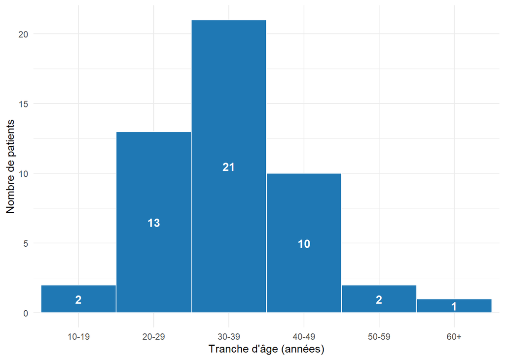

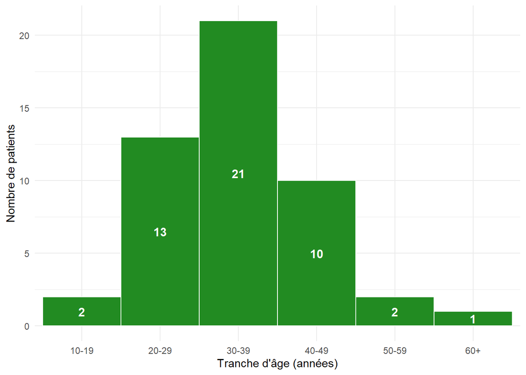

Les âges des patients varient de 10 à 63 ans, avec une moyenne de 34,5 +/- 10,2 ans. La tranche d’âge la plus représentée est celle des 30-39 ans (n = 21; 42,9%), suivie des 20-29 ans (n = 13; 26,5%).

Les femmes (n = 29; 59,2%)) représentent près de 3/5 des patients.

## Motifs de consultation

| motif_de_consultation | n | pct |
| --- | --- | --- |
| Lésions solides | 35 | 71.4 |
| Douleur | 20 | 40.8 |
| Lésions liquidiennes | 12 | 24.5 |
| Écoulement purulent | 5 | 10.2 |

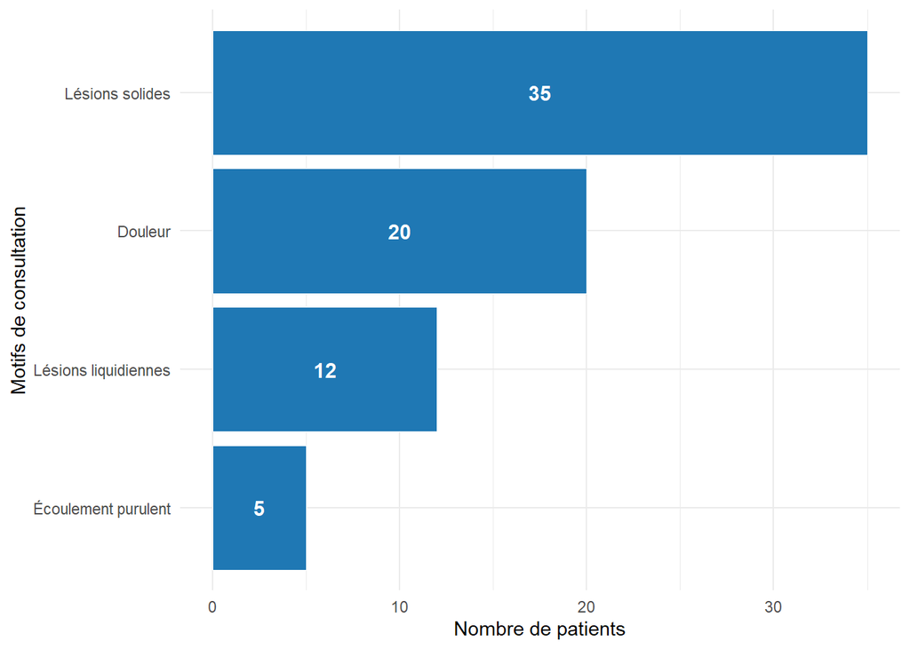

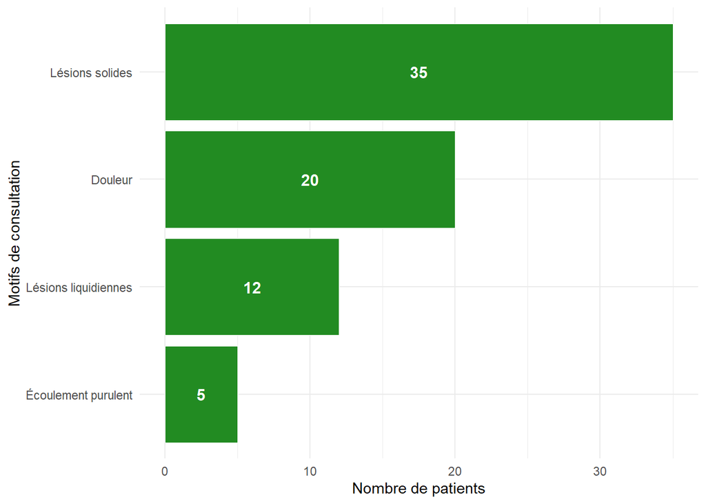

## Délai d’évolution

```
##
##  Shapiro-Wilk normality test
##
## data:  mdv$delai_devolution_en_mois
## W = 0.83295, p-value = 1.999e-05
```

```
##    Min. 1st Qu.  Median    Mean 3rd Qu.    Max.    NA's
##    0.00    7.00   24.00   31.44   48.00  120.00       6
```

Pour les 43 patients dont les données sont disponibles, le délai d’évolution de la maladie varie de 0 à 120 mois, avec une médiane de 24 mois (IQR 7-48).

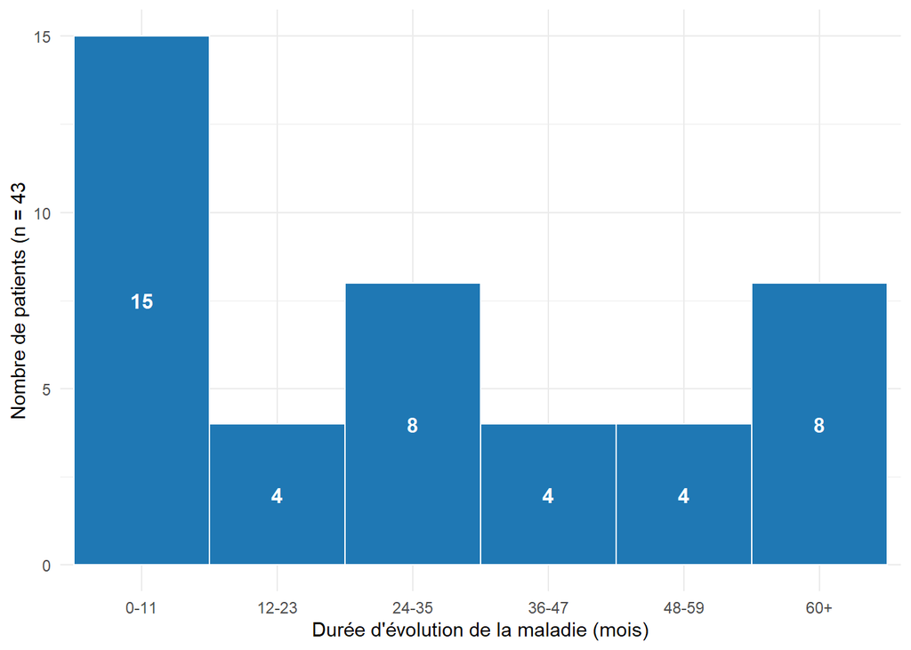

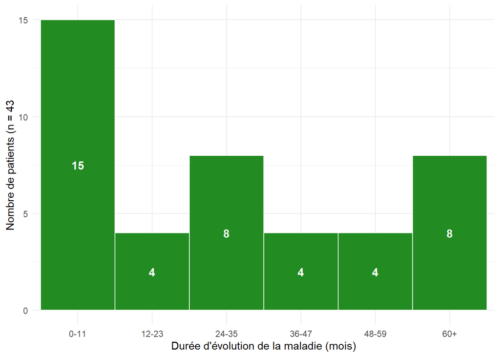

## Facteurs de risque retrouvé

| facteurs_de_risque | n | pct | csum | pos |
| --- | --- | --- | --- | --- |
| Aucun | 29 | 59.2 | 51 | 36.5 |
| Obésité | 7 | 14.3 | 22 | 18.5 |
| Non précisé | 6 | 12.2 | 15 | 12 |
| Hérédité | 5 | 10.2 | 9 | 6.5 |
| Tabac | 4 | 8.2 | 4 | 2 |

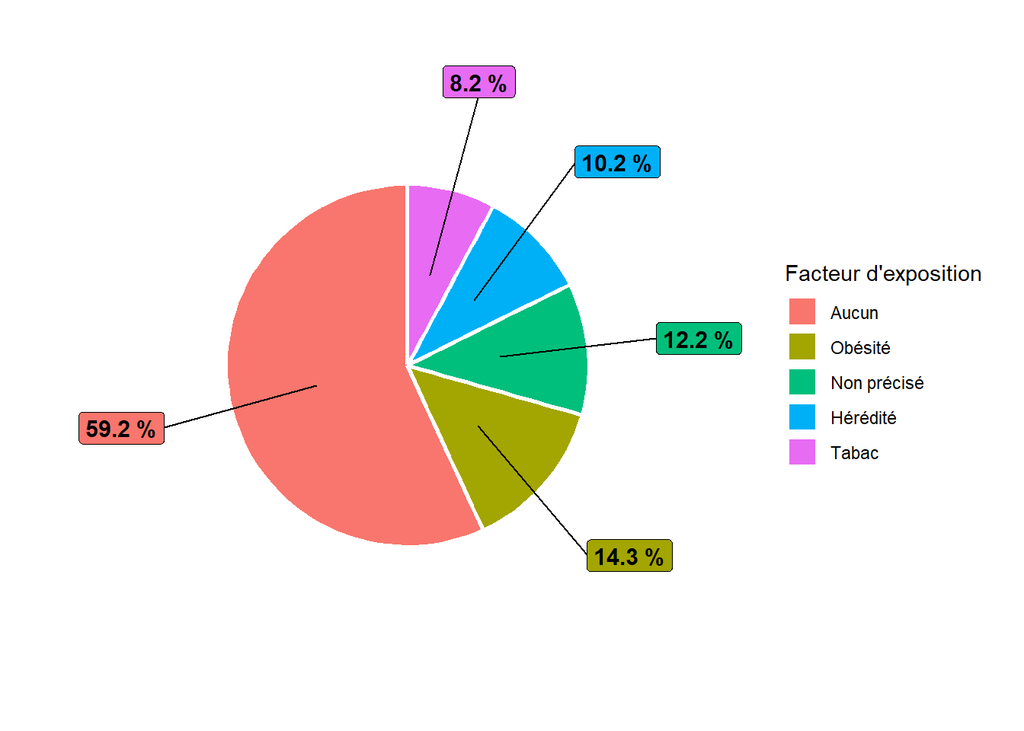

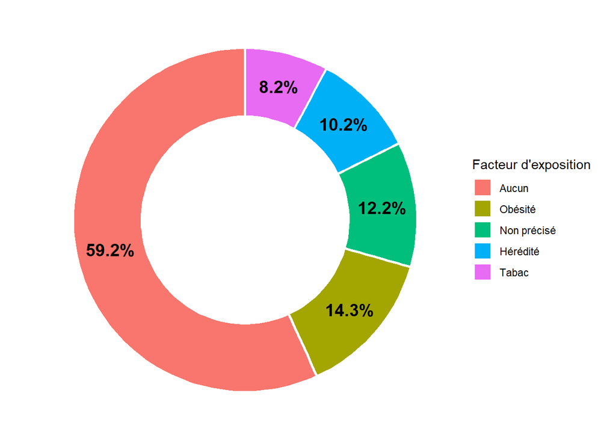

## Siège de début des lésions

| siege_de_debut | n | pct | csum | pos |
| --- | --- | --- | --- | --- |
| Aisselles | 36 | 73.5 | 52 | 34 |
| Visage | 5 | 10.2 | 16 | 13.5 |
| Non précisé | 4 | 8.2 | 11 | 9 |
| Fesses | 3 | 6.1 | 7 | 5.5 |
| Pubis | 3 | 6.1 | 4 | 2.5 |
| Périnée | 1 | 2 | 1 | 0.5 |

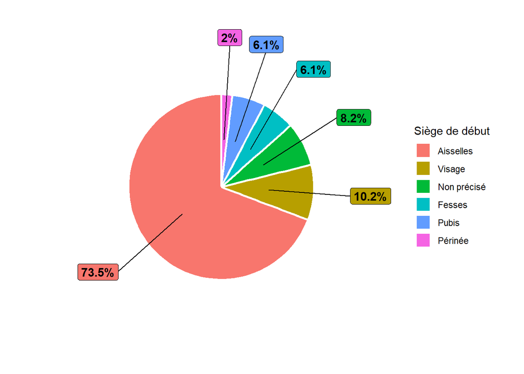

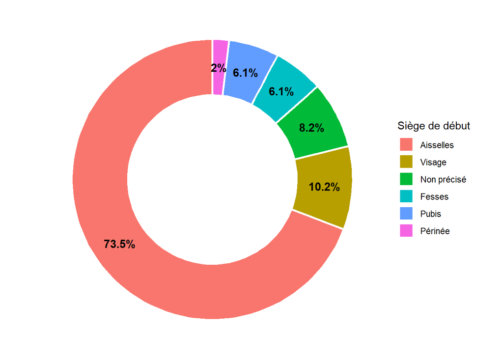

Au début de la maladie, les lésions sont majoritairement situées/localisées aux aisselles, en l’occurrence chez 36 patients (73,5%), suivies du visage, notamment chez cinq (10,2%) patients. Trois patients (6,1%) ont des lésions sur deux sites.

## Siège actuel des lésions

| sieges | n | pct | csum | pos |
| --- | --- | --- | --- | --- |
| Aisselles | 41 | 83.7 | 89 | 68.5 |
| Pubis | 15 | 30.6 | 48 | 40.5 |
| Fesses | 12 | 24.5 | 33 | 27 |
| Visage | 5 | 10.2 | 21 | 18.5 |
| Cuir chevelu | 4 | 8.2 | 16 | 14 |
| Plis inguinaux | 4 | 8.2 | 12 | 10 |
| Périnée | 3 | 6.1 | 8 | 6.5 |
| Autres | 2 | 4.1 | 5 | 4 |
| Seins | 2 | 4.1 | 3 | 2 |
| Dos | 1 | 2 | 1 | 0.5 |

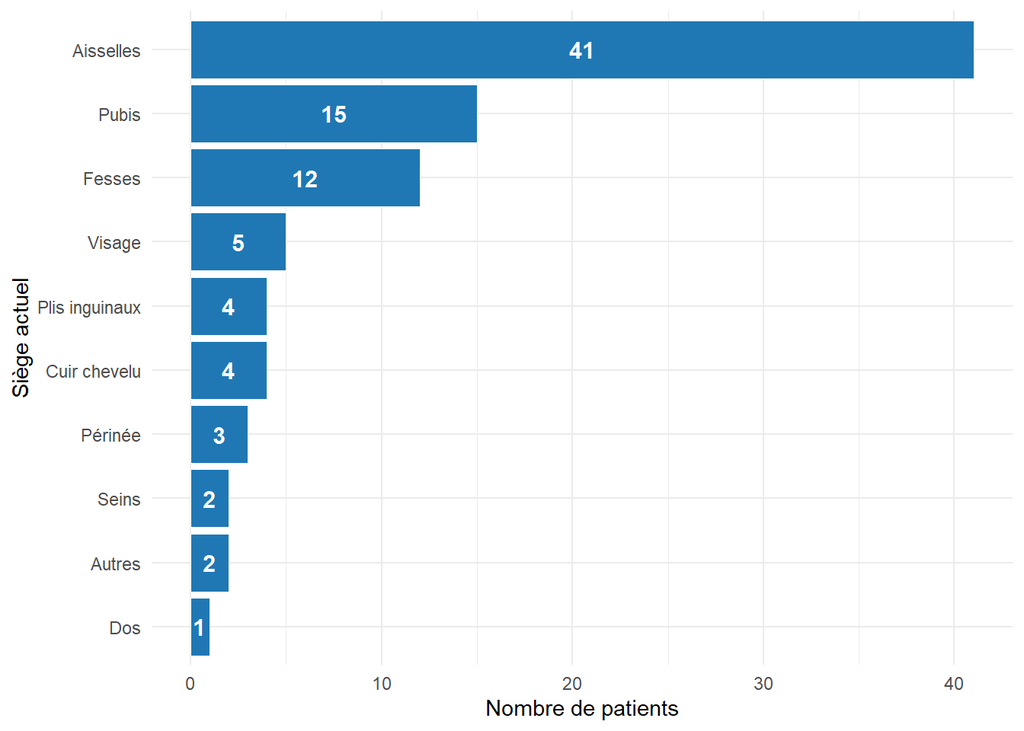

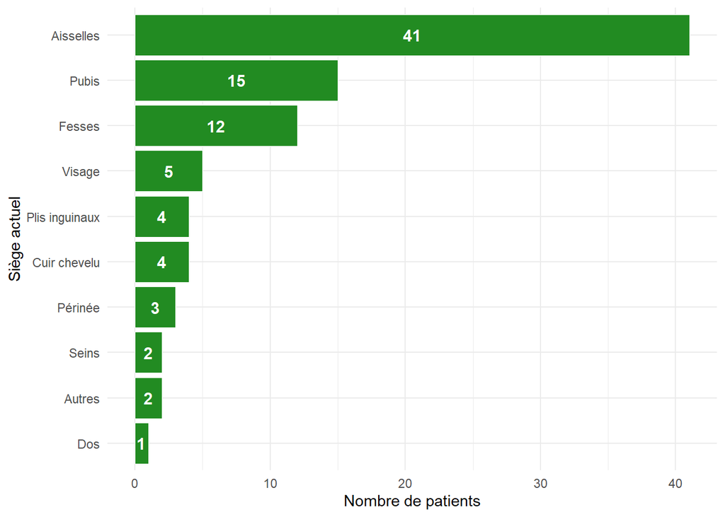

## Types de lésions

| types_de_lesions | n | pct |
| --- | --- | --- |
| Nodules | 39 | 79.6 |
| Masses abcedées | 23 | 46.9 |
| Fistules | 19 | 38.8 |
| Trajet sinueux | 6 | 12.2 |
| Cicatrices en pont | 3 | 6.1 |
| Cicatrices en crabes | 2 | 4.1 |

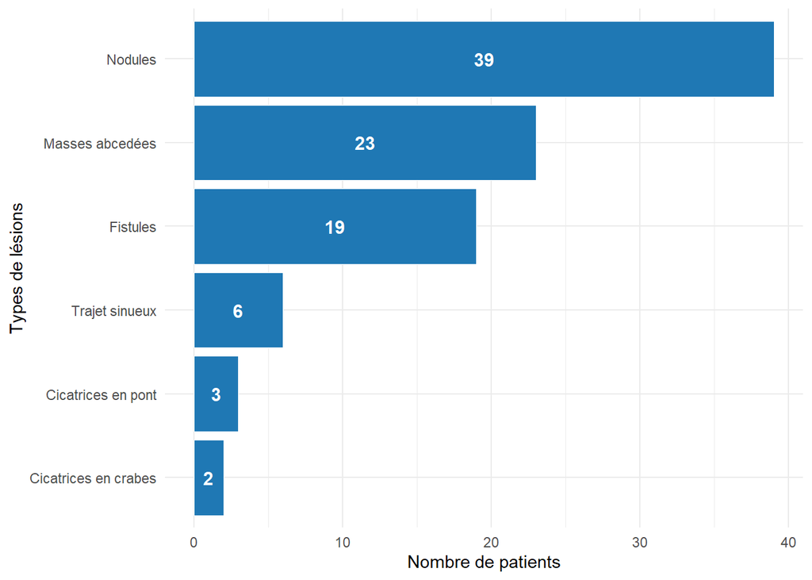

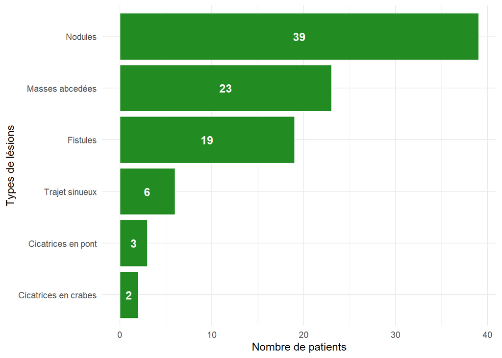

Les nodules représentent la lésion la plus prépondérante, onjectivée chez 39 patients (79,6). Ensuite sont retrouvées les masses abcédées, notamment chez 23 patients (46,9%), et les fistules chez 19 patients (38,8%). Par ailleurs, près de 32 patients (65,3%) ont plus d’un type de lésions.

## Classification clinique de Hurley

| classification_de_hurley | n | pct | csum | pos |
| --- | --- | --- | --- | --- |
| Stade 1 | 28 | 57.1 | 49 | 35 |
| Stade 2 | 19 | 38.8 | 21 | 11.5 |
| Stade 3 | 2 | 4.1 | 2 | 1 |

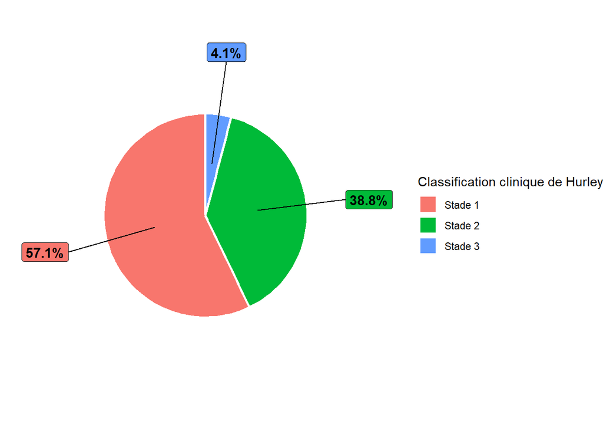

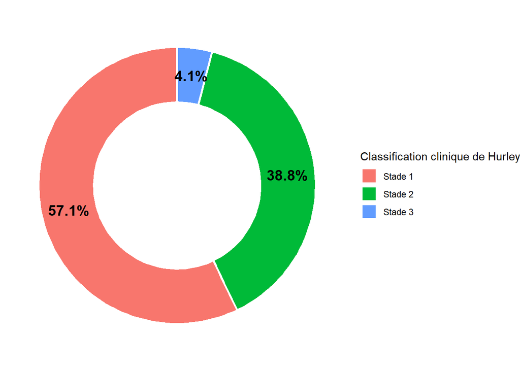

Plus de la moitié des patients (n = 28; 57,1%) sont au stade 1 de la maladie tandis que 19 patients (38,8%) sont au stade 2. Seuls 2 patients (4,1%) sont au stade 3 de la maladie.

## Qualité de vie

```
##
##  Shapiro-Wilk normality test
##
## data:  mdv$total_dlqi
## W = 0.70405, p-value = 3.094e-05
```

```
##    Min. 1st Qu.  Median    Mean 3rd Qu.    Max.    NA's
##   1.000   2.000   2.000   3.714   4.000  13.000      28
```

Des 21 patients pour lesquels l’information est disponible, le score DLQI varie de 1 à 13, avec une médiane de 2 (EIQ: 2-4).

| qdv | n | pct |
| --- | --- | --- |
| Données non disponibles | 28 | 57.1 |
| Faible altération | 12 | 24.5 |
| QdV non altérée | 5 | 10.2 |
| Altération importante | 2 | 4.1 |
| Altération modérée | 2 | 4.1 |

Aucun patient ne présente une altération extrêmement importante. Cependant, 4 patients (8,2%) présentent une altération modérée à importante de la QdV. En outre, 12 patients (24,5%) présentent une faible altération de la QdV tandis que 5 patients (10,2%) ne présentent aucune altération de leur QdV.

| qdv | n | pct | csum | pos |
| --- | --- | --- | --- | --- |
| Faible altération | 12 | 57.1 | 21 | 15 |
| QdV non altérée | 5 | 23.8 | 9 | 6.5 |
| Altération importante | 2 | 9.5 | 4 | 3 |
| Altération modérée | 2 | 9.5 | 2 | 1 |

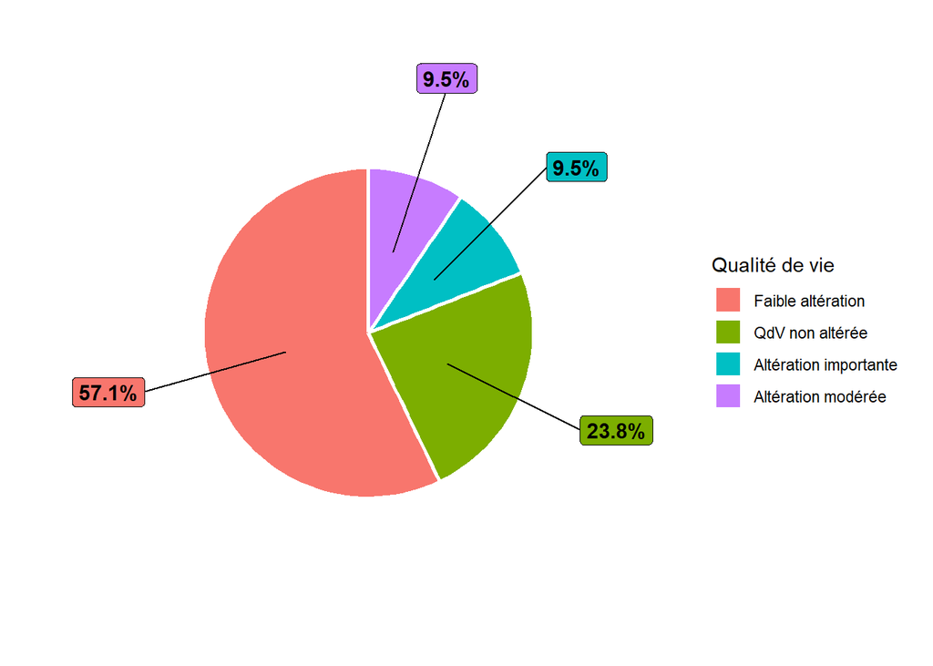

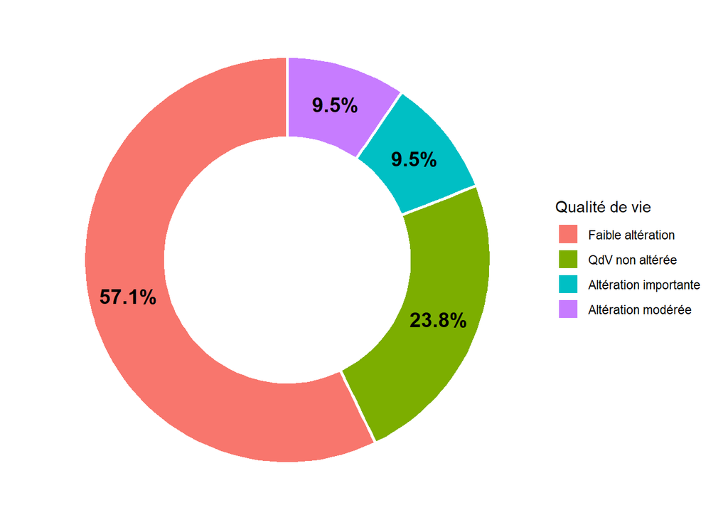

# Analyse bivariée

## Relation entre siège de début et siège actuel des lésions

| siege_de_debut | sieges | n | pct |
| --- | --- | --- | --- |
| Aisselles | Aisselles | 16 | 32.7 |
| Aisselles | Aisselles Autres (Si autres préciser) Seins | 1 | 2 |
| Aisselles | Aisselles Dos | 1 | 2 |
| Aisselles | Aisselles Fesses Autres (Si autres préciser) | 1 | 2 |
| Aisselles | Aisselles Fesses Pubis | 2 | 4.1 |
| Aisselles | Aisselles Fesses Pubis Plis inguinaux | 2 | 4.1 |
| Aisselles | Aisselles Plis inguinaux | 1 | 2 |
| Aisselles | Aisselles Pubis | 7 | 14.3 |
| Aisselles | Cuir chevelu Aisselles Fesses | 1 | 2 |
| Aisselles | Cuir chevelu Aisselles Fesses Pubis | 1 | 2 |

[output cut: 13 more lines]

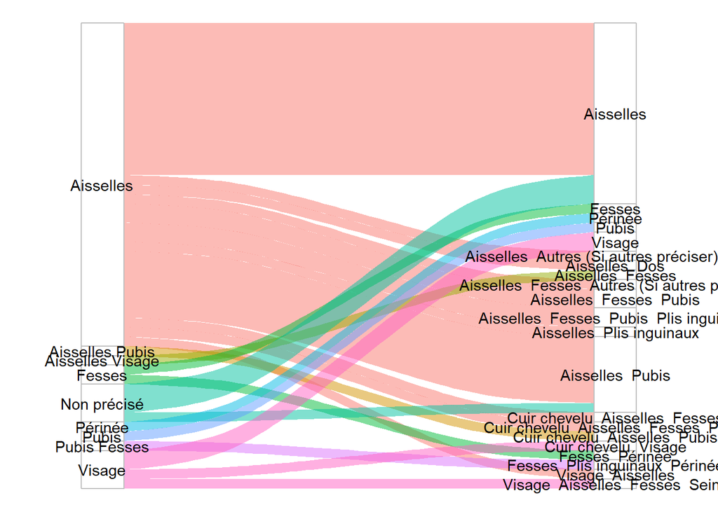

## Distribution de la QdV selon le sexe

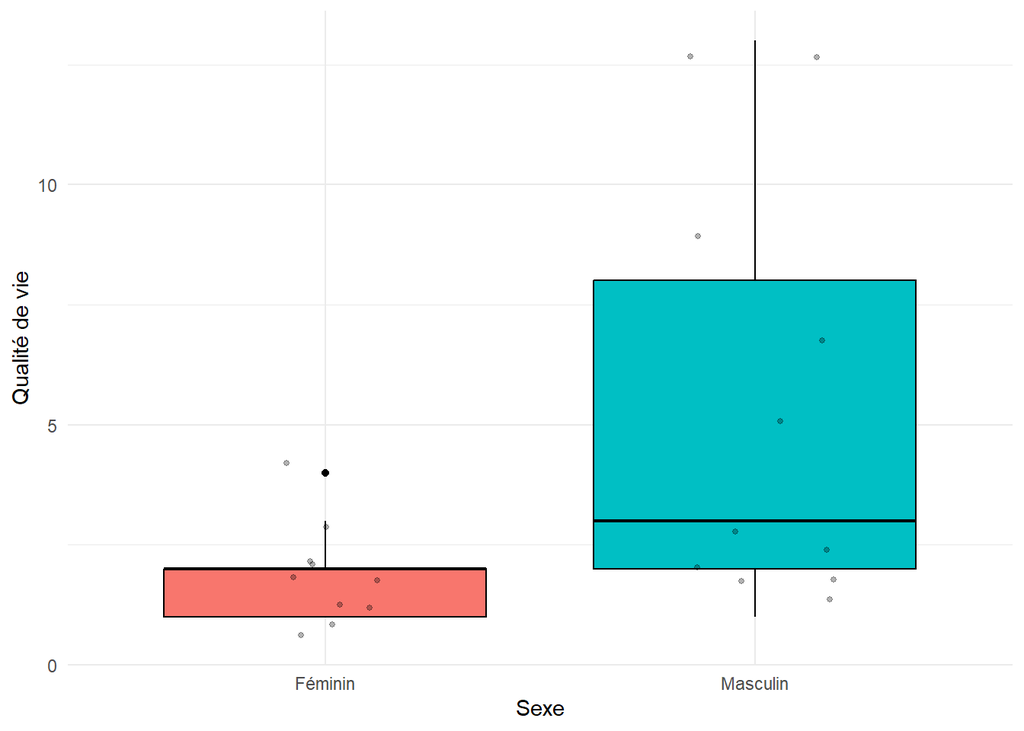

```
##
##  Wilcoxon rank sum test with continuity correction
##
## data:  total_dlqi by sexe
## W = 25.5, p-value = 0.03432
## alternative hypothesis: true location shift is not equal to 0
```

| sexe | median | first_q | third_q |
| --- | --- | --- | --- |
| Féminin | 2 | 1 | 2 |
| Masculin | 3 | 2 | 8 |

Une comparaison des scores de qualité de vie entre hommes et femmes montre que les hommes ont une tendance à une altération de qdv plus marquée que chez les femmes, avec une différence statistiquement signficative: médiane 3 (EIQ 2-8) vs 2,0 (EIQ 1-2); p = 0,034 (Figure 10).

## Qualité de vie et stade de la maladie

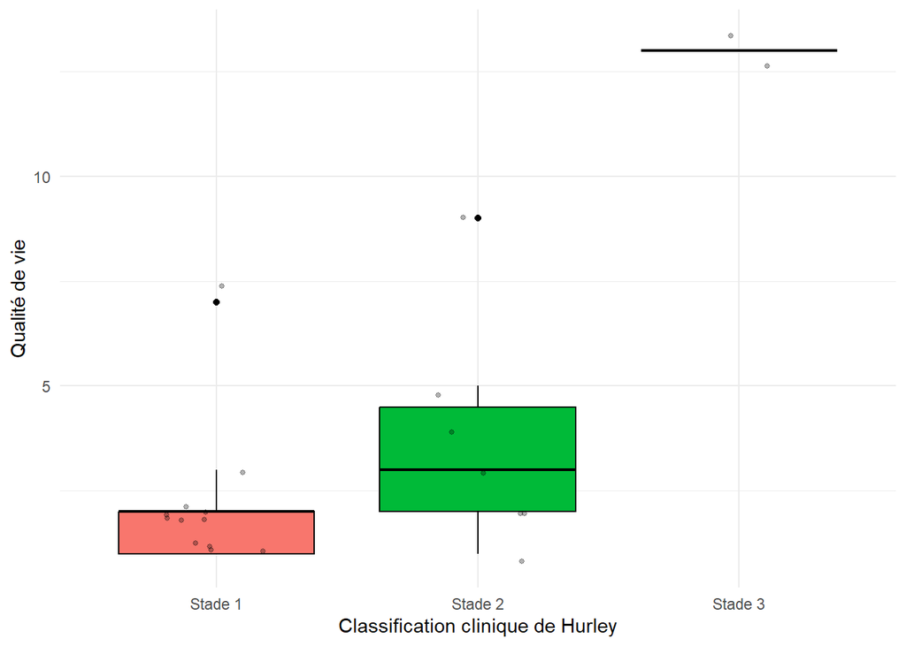

```
##
##  Kruskal-Wallis rank sum test
##
## data:  total_dlqi by classification_de_hurley
## Kruskal-Wallis chi-squared = 7.7242, df = 2, p-value = 0.02102
```

| classification_de_hurley | median | first_q | third_q |
| --- | --- | --- | --- |
| Stade 1 | 2 | 1 | 2 |
| Stade 2 | 3 | 2 | 4.5 |
| Stade 3 | 13 | 13 | 13 |

La figure 12 montre clairement que le score de qualité de vie semble intimement lié au stade de la maladie. En effet, l’altération de la qualité de vie semble s’ampirer avec le stade de la maladie, avec une différence statistiqument significative entre les trois stades: médiane 2 (EIQ 1-2) vs 3 (EIQ 2-4,5) vs 13 (EIQ 13-13) respectivement pour les stades 1, 2 et 3; p = 0,02.

## Corrélation entre qualité de vie et durée d’évolution de la maladie

```
##
##  Spearman's rank correlation rho
##
## data:  mdv_corr$delai_devolution_en_mois and mdv_corr$total_dlqi
## S = 1410.4, p-value = 0.7168
## alternative hypothesis: true rho is not equal to 0
## sample estimates:
##        rho
## 0.08418363
```

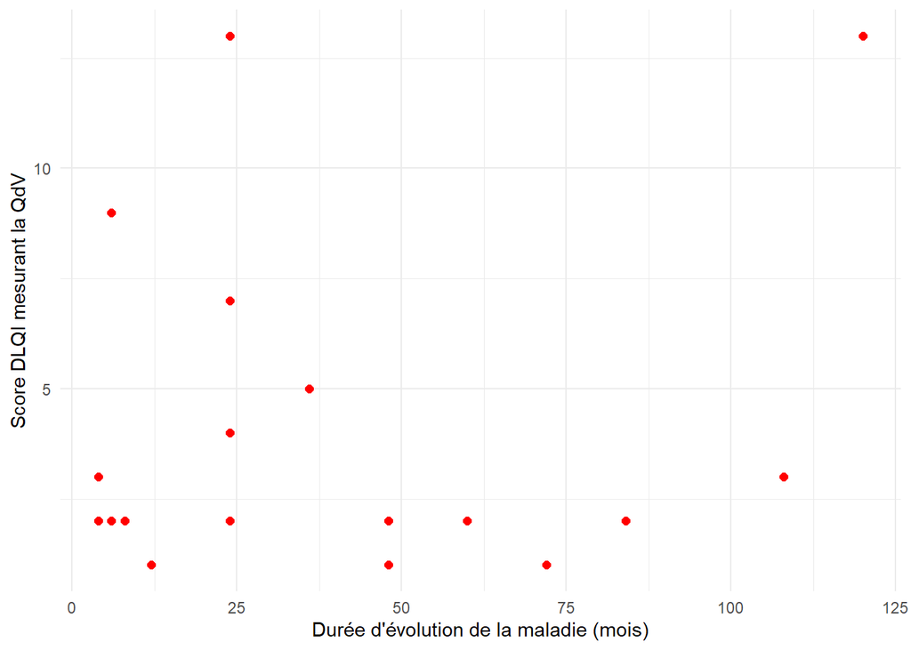

```
##    Min. 1st Qu.  Median    Mean 3rd Qu.    Max.    NA's
##    0.00    7.00   24.00   31.44   48.00  120.00       6
```

```
## [1] 31.57403
```

```
## # A tibble: 6 × 1
##   summary
##   <table[1d]>
## 1   4.0
## 2  11.0
## 3  24.0
## 4  36.2
## 5  51.0
## 6 120.0
```

## Sexe et sévérité de la maladie

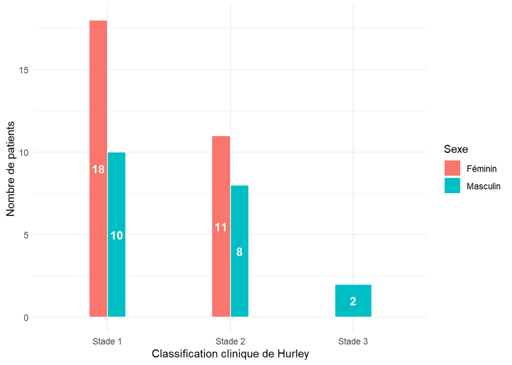

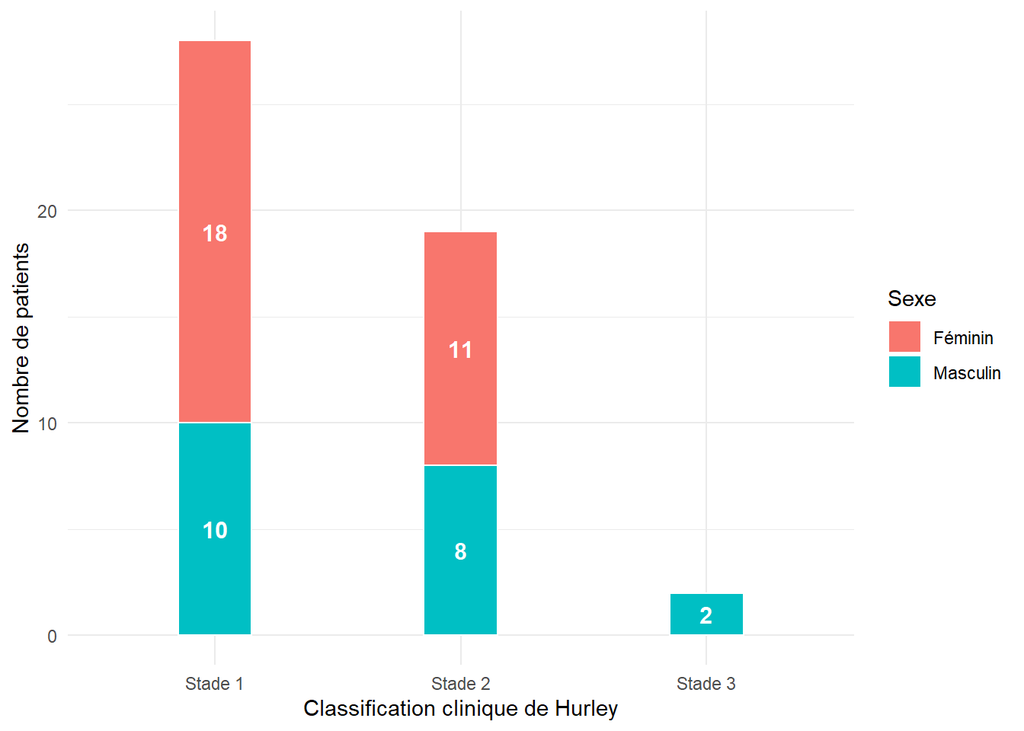

La figure 14 montre que des 28 patients au stade I de la maladie, 18 (64,3%) sont de sexe féminin; des 19 patients au stade II, 11 (57,9%) sont de sexe féminin. Les deux patients au stade III sont tous de sexe masculin. Cependant, il n’y avait pas de différence significative entre hommes et femmes vis-à-vis de la sévérité de la maladie (Chi-2 = 3,215; p = 0,200).

```
##
##  Pearson's Chi-squared test
##
## data:  xtabs(n ~ sexe + classification_de_hurley, data = .)
## X-squared = 3.2148, df = 2, p-value = 0.2004
```

## Sexe et facteurs d’exposition

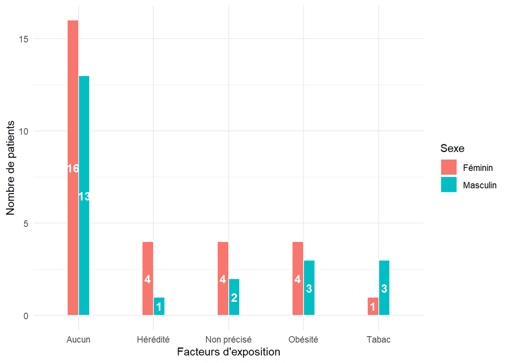

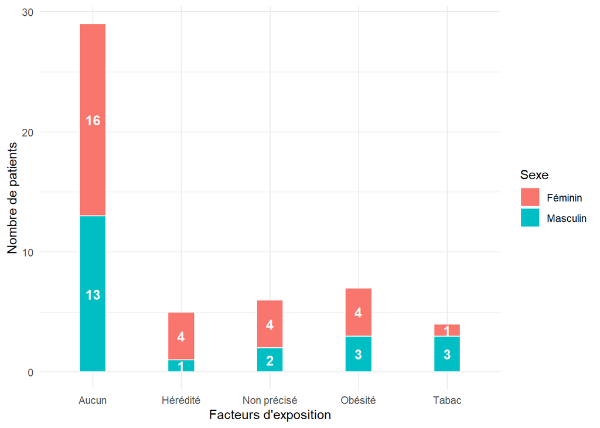

```
##
##  Pearson's Chi-squared test
##
## data:  xtabs(n ~ sexe + facteurs_de_risque, data = .)
## X-squared = 5.0959, df = 5, p-value = 0.4043
```

Des 7 et 5 patients présentant une obésité et des antécédents familiaux de MDV, 4 (57,1% et 80,0% respectivement) étaient des femmes tandis que des 4 patients fumeurs, 3 (75,0%) étaient des hommes. Il n’y a pas de différence entre hommes et femmes sur les facteurs d’exposition (Chi-2 = 5,10; p = 0,404).

## Facteurs d’exposition et QdV

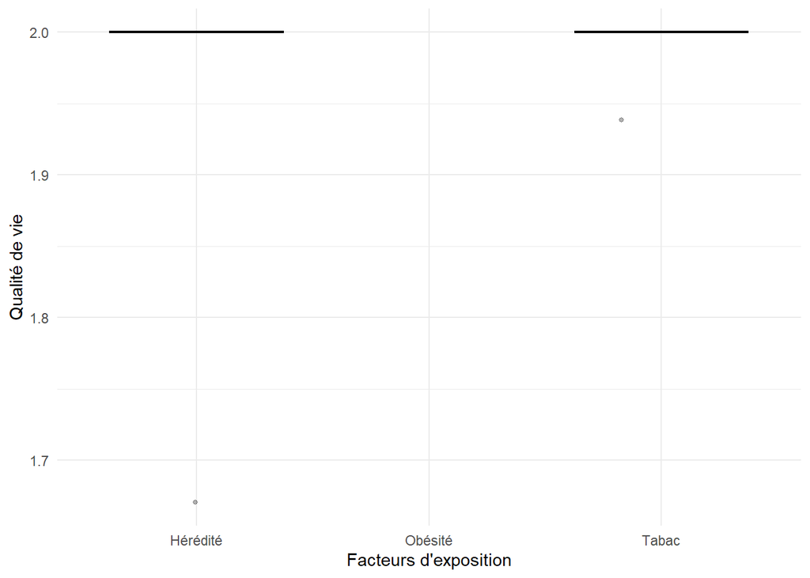

```
##
##  Kruskal-Wallis rank sum test
##
## data:  total_dlqi by facteurs_de_risque
## Kruskal-Wallis chi-squared = 2.1317, df = 4, p-value = 0.7115
```

La figure 16 montre qu’il n’y a pas de différence dans l’altération de la qualité de vie entre les patients ayant les trois comorbidités répertoriées, notamment obésité, tabac et hérédité/ATCD familiaux de MDV (p = 0,712).